# Quit using AI agents

I’m an excessive ai chatbot user. It is basically my mode of action to explain what I want to do to an ai and if it’s code I use whatever they give me back for coding. I’m increasingly coming to the realization that these AI bots are more burden than help. Today I spnet my morning trying to use quarto to have a convenient format for scientific microposting. I spnet hours trying to make it work. It turned out the line ‘%matplotlib inline’ was necessary to get my plot rendered. This is a completely boilerplate line which presumably any online tutorial would have covered. But me using Gemini and Cursor, I spent hours going back and forthe between code and chat and pasting error messages and explaining what happened. Finally it worked but it is very draining. What is more the learning effect seems significantly reduced when using chat bots. the seeming ease of getting instant code is offset by the loss of understanding of the code base and atrophied coding skills. Before moving to ai assisted coding, coding was googling, finding work on similar problems, understanding them to the point that they could be adapted to my problem and then implementing that modified version. It led to deep understanding of the code base and complete oversight. I will at least insert 2-3h morning blocks without ai assistence. let’s see how it goes.

# A Test Header

This is my first post in my new format, Quarto. It should be useful to create scientific microposts that combine Text and code seamlessly. It doesn’t have any grammar or spelling correction so I will make mistakes but that is fine.

# A Test Plot

Here an example plot and example code.

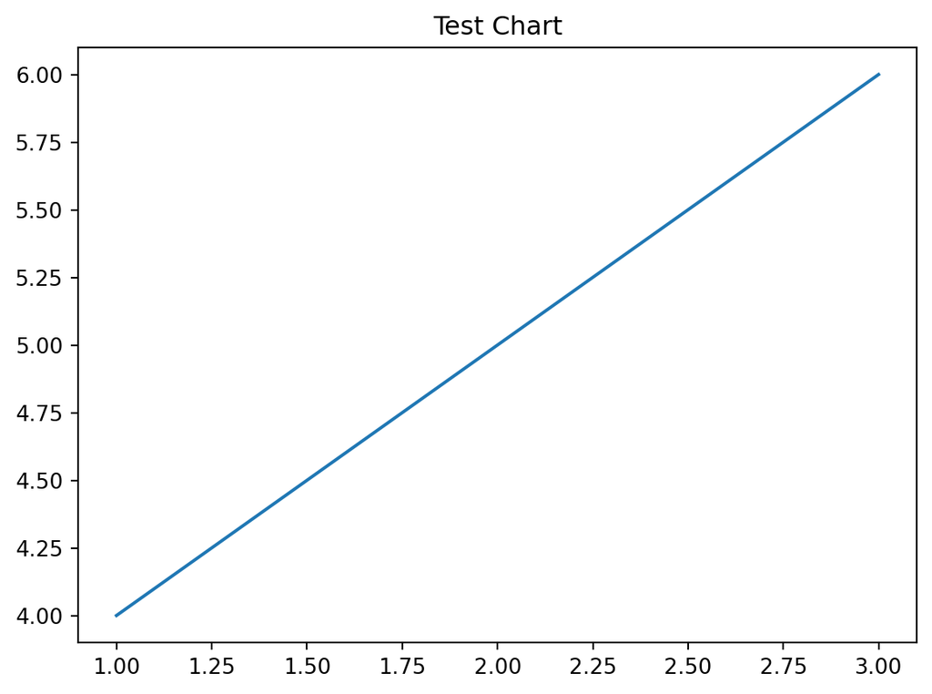

```python
%matplotlib inline
import matplotlib.pyplot as plt

plt.plot([1, 2, 3], [4, 5, 6])
plt.title("Test Chart")
```